# si670f20_hw_7

## SI 670 Applied Machine Learning, Homework 7: Deep Learning

For this assignment, question 1 is worth 50 points, and question 2 is worth 40 points, for a total of 90 points. Correct answers and code receive full credit, but partial credit will be awarded if you have the right idea even if your final answers aren't quite right.

Submit your completed notebook file AND corresponding **HTML** file to the Canvas site.

As a reminder, the notebook code you submit must be your own work. Feel free to discuss general approaches to the homework with classmates: if you end up forming more of a team discussion on multiple questions, please include the names of the people you worked with at the top of your notebook file.

### Put your name here:

### Put your uniquename here:

### Question 1 Comparing ML with DL (50 points)

In this question, we are still exploring classifying the IMDB movie data set as we did in the lab. You will use the different classifiers you learned in this course: (1) LinearSVC; (2) RandomForestClassifier; (3) Deep learning.

### Preprocessing

```python
from keras.datasets import imdb

(train_data, train_labels), (test_data, test_labels) = imdb.load_data(num_words=10000)

import numpy as np

def vectorize_sequences(sequences, dimension=10000):
    # Create an all-zero matrix of shape (len(sequences), dimension)
    results = np.zeros((len(sequences), dimension))
    for i, sequence in enumerate(sequences):
        results[i, sequence] = 1.  # set specific indices of results[i] to 1s
    return results

# Our vectorized training data
x_train = vectorize_sequences(train_data)
# Our vectorized test data
x_test = vectorize_sequences(test_data)

# Our vectorized labels
y_train = np.asarray(train_labels).astype('float32')
y_test = np.asarray(test_labels).astype('float32')
```

```
Downloading data from https://storage.googleapis.com/tensorflow/tf-keras-datasets/imdb.npz
```

### Question 1(a) (10 points)

Please use LinearSVC to train the model and return the mean accuracy on the given test data and labels. You can use the default parameteers in LinearSVC.

```python
def answer_one_a():
    from sklearn.svm import LinearSVC
    clf = LinearSVC(random_state=0)
    clf.fit(x_train, y_train)
    mean_accuracy = clf.score(x_test,y_test)
    return mean_accuracy
print(answer_one_a())
```

```
0.8354
```

### Question 1(b) (10 points)

Please use RandomForestClassifier (with random_state = 0) to train the model and return the mean accuracy on the given test data and labels.

```python
def answer_one_b():
    from sklearn.ensemble import RandomForestClassifier
    clf = RandomForestClassifier(random_state=0).fit(x_train,y_train)
    test_score = clf.score(x_test,y_test)
    return test_score
print(answer_one_b())
```

```
0.84384
```

### Question 1(c) (20 points)

Please use the below architecture of the dense layers to design your model: one intermediate layers with 32 hidden units, and a second layer which will output the scalar prediction regarding the sentiment of the current review.

The intermediate layer will use `relu` as its "activation function", and the final layer will use a sigmoid activation so as to output a probability (a score between 0 and 1, indicating how likely the sample is to have the target "1", i.e. how likely the review is to be positive). A `relu` (rectified linear unit) is a function meant to zero-out negative values, while a sigmoid "squashes" arbitrary values into the `[0, 1]` interval, thus outputting something that can be interpreted as a probability.

We configure our model with the `rmsprop` optimizer and the `binary_crossentropy` loss function as we did in the lab. Note that we will also monitor accuracy during training.

For model fitting, we train our model for 4 epochs (4 iterations over all samples in the x_train and y_train tensors), in mini-batches of 512 samples.

Please return the testing accuracy.

```python
def answer_one_c():
    from keras import models
    from keras import layers

    #write your code here
    model = models.Sequential()
    model.add(layers.Dense(32, activation='relu', input_shape=(10000,)))
    model.add(layers.Dense(1, activation='sigmoid'))

    model.compile(optimizer='rmsprop',
                  loss='binary_crossentropy',
                  metrics=['accuracy'])

    model.fit(x_train, y_train, epochs=4, batch_size=512)
    results = model.evaluate(x_test, y_test)
    return results

answer_one_c()
```

```
[0.291637122631073, 0.8828799724578857]
```

### Question 1(d) Open Question (10 points)

Can you conclude that deep learning is better than the classic ML models on this task? If so, what do you think that helps Deep Learning perform better? If not, tells us your reasons.

From the testing above, the Deep Learning performs better than LinearSVM and Random Forest because Deep Learning can do layer-by-layer processing and as a result, the whole process can do the feature transformation and the process from a layer to the next layer is a new and complete procedure of learning.

## Question 2 Hyper-parameteer tunning in DL (40 points)

We have shown you how to tune parameters such as training epoch in the lab.

In this question, we are exploring the hyper-parameteer tuning in deep learning from the perspective of the size of the network.

First, we divide some part of training data into valiadation data.

```python
x_val = x_train[:10000]
partial_x_train = x_train[10000:]

y_val = y_train[:10000]
partial_y_train = y_train[10000:]
```

### Question 2(a): (30 points)

Follow the IMDB classification question in Question 1, we hope you design and test different neural network. You shall vary the first intermediate layer with [3, 6, 9, 12] hidden units, and the second intermediate layer with [2, 4, 6, 8] hidden units.

The last layer which will output the scalar prediction regarding the sentiment of the current review.

Apply the different models onto the valiadation set and return the best model with highest accuracy on the valiadation. You should three numbers, which represent the best model's number of hideen units in first, second intermediate layer, and the best accuracy.

Fit the model by using the default setting in 1(c). (epochs = 4, batch_sze = 512, optimizer = rmsprop, loss = binary_crossentropy, metrics = 'accuracy')

```python
def answer_two_a():
    from keras import models
    from keras import layers
    from keras import metrics

    best_first, best_second, best_res = 0, 0, 0


    for first_layer in [3, 6, 9, 12]:
        for second_layer in [2, 4, 6, 8]:
            # write the code here
            model = models.Sequential()
            model.add(layers.Dense(first_layer, activation='relu', input_shape=(10000,)))
            model.add(layers.Dense(second_layer,activation='relu'))
            model.add(layers.Dense(1, activation='sigmoid'))

            model.compile(optimizer='rmsprop',
                        loss='binary_crossentropy',
                        metrics=['accuracy'])

            history = model.fit(partial_x_train, partial_y_train, epochs=4,
                    validation_data=(x_val, y_val))
            max_acc = max(history.history['val_accuracy'])
            if max_acc > best_res:
                best_res = max_acc
                best_first = first_layer
                best_second = second_layer

    return best_first, best_second, best_res

answer_two_a()
```

```python
from google.colab import files
from IPython.display import Image
uploaded = files.upload()
```

Upload widget is only available when the cell has been executed in the current browser session. Please rerun this cell to enable.

```
Saving result.PNG to result.PNG
```

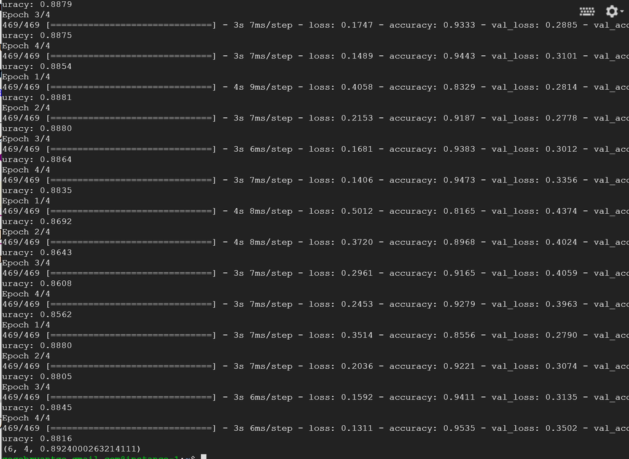

```python
Image('result.PNG', width=525)
```

### Question 2(b): (10 points)

According to the performance we observed for three models? Which design is best for this task?

What take-away do you get from this question? Does it mean larger network improve the model's performance?

Base on the result shown above, the first layer should have 6 units and the second layer should have 4 units. According to the observation above, larger network does not necessarly result better performance on the validation data because there will effect of overfitting.